# **Advanced Data Structures with Java: Class Design & BFS Search**

B McDougall

11 Feb 2016

## Executive Summary

Work is summarized that demonstrates Class Design, an Abstract Data Type (ADT), and Breadth First Search (BFS). A java code template is provided by UC San Diego faculty. The skeleton code is comprised of 262 files in 51 directories. Development excutes with Java JDK 1.8.0_60-b27 in an Eclipse Version: Mars.1 Release (4.5.1) environment. Version control executes with git version 1.9.5.msygit.0. After BFS successfully implemented, the code is 273 files with 51 directories. Code development includes completion of method stubs and the addition of six methods in the provided class **MapGraph.java**. Code development also includes addition of two additional classes with a combined count of twenty-six methods. The revised class and additional classes are contained in the package *roadgraph*.

## Project Summary

The project delivers (1) geographic routing between start and destination locations and (2) visualization of the graph nodes visited during BFS. The code demonstrates class design that implements two constructs: (1) ADT and (2) BFS. The ADT is a graph that stores data using a [HashMap](http://docs.oracle.com/javase/8/docs/api/java/util/HashMap.html). Geographic location data is stored in an object that is named GeographicPoint (GP) and that extends the [Object.Number.Double](http://docs.oracle.com/javase/7/docs/api/java/lang/Double.html) class. Routes and visited nodes are visualized using the [Google Map API](https://www.google.com/work/mapsearth/products/mapsapi.html).

## Introduction

A graph is a construction that contains nodes and edges. Nodes are objects that contain data, and edges represent directed connections between nodes. In the context of geographic map data, a GP represents a node and roads represent edges connecting these nodes. Developed code is in `MapGraph.java`, `mapVertex.java`, and `mapEdge.java` classes of the `roadgraph` package. Figure 1 shows an UML diagram for five of the seven classes in `roadgraph` package. The remaining two classes are shown in figure 2.

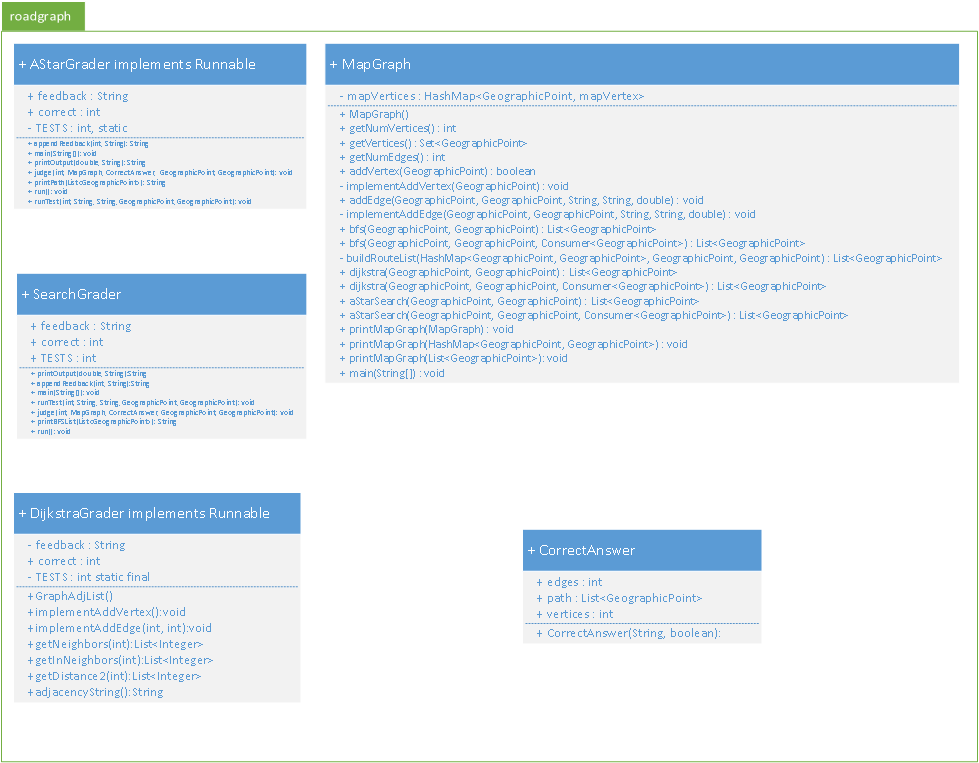

Figure 2 shows an UML diagram representing the nodes and edges of the graph ADT. The methods for the classes `MapGraph.java`, `mapVertex.java`, and `mapEdge.java` are described in the **Methods** section.

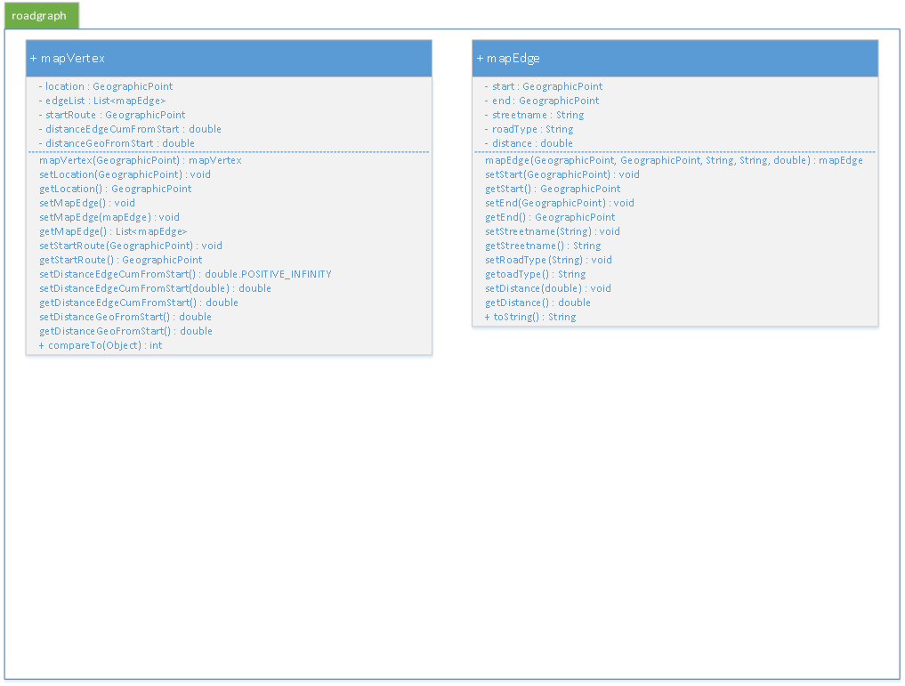

## Methods

The pseudocode for BFS is:

```
bfs(start, destination, Consumer<GP>):
Initialization of structures
Enqueue GP in queue and add to list of visited GP's
while queue is not empty:
    dequeue GP from front of queue as current
    if current == destination, then return parent map
    for each of current's unvisited neighbors, n:
        add n to visited set
        add current as n's parent in parent map
        enqueue n to back of queue
if parent map not returned, then there is no path
```

Consumer<GP> is a hook that passes nodes visited during BFS search to the class that provides a visual representation of the visited nodes.

### Class name: mapVertex

The class mapVertex represents a GP as a node. The mapVertex node also contains a list of mapEdge()’s that represent roads that connect a GP to other GP’s in the MapGraph(). Data are private, so getter/setter methods are used to pass data to and from a mapVertex() instance. Figure 2 lists the setter/getter methods.

- **mapVertex(GeographicPoint) : mapVertex** constructs the node object of the graph.
- **setLocation(GeographicPoint) : void** is a setter for the GP location of mapVertex.
- **getLocation() : GeographicPoint** is a getter that returns the GP location of mapVertex.
- **setMapEdge() : void** is a setter for generating an empty array list of edges for mapVertex.
- **setMapEdge(mapEdge) : void** is a setter for adding an edge to an array list of edges associated with mapVertex.
- **getMapEdge() : List** is a getter that returns the array list of edges for mapVertex.
- **setStartRoute(GeographicPoint) : void** is a setter for the global start location for a search algorithm that uses mapVertex.
- **getStartRoute() : GeographicPoint** is a getter that returns the global start location for a search algorithm that uses mapVertex..
- **setDistanceEdgeCumFromStart() : double.POSITIVE_INFINITY** is a setter for the initial priority of mapVertex for weighted search algorithms.
- **setDistanceEdgeCumFromStart(double) : double** is a setter for updated priority of mapVertex for weighted search algorithms.
- **getDistanceEdgeCumFromStart() : double** is a getter that returns the distance of mapVertex from the global start by traversing map edges.
- **setDistanceGeoFromStart() : double** is a setter for the geographic distance of mapVertex from the global start location.
- **getDistanceGeoFromStart() : double** is a getter for the geographic distance of mapVertex from the global start location.
- **compareTo(Object) : int** is a method that establishes a comaparison of priorities of the nodes that are in priority queues.

### Class name: mapEdge

The class mapEdge is a graph edge that represents roads connecting GP’s. The graph is a di-Graph; therefore, an instance of mapEdge() contains a start node and an end node. The mapEdge object also contains other geographic data: street name, distance between the start and end GP’s, and type of road. Data are private, so getter/setter methods pass data to and from a mapEdge() instance. Figure 2 lists the setter/getter methods.

- **mapEdge(GeographicPoint, GeographicPoint, String, String, double) : mapEdge** constructs the mapEdge object.
- **setStart(GeographicPoint) : void** is a setter for the start GP of an edge.
- **getStart() : GeographicPoint** is a getter for the start GP of an edge.
- **setEnd(GeographicPoint) : void** is a setter for the end GP of an edge.
- **getEnd() : GeographicPoint** is a getter for the end GP of an edge.
- **setStreetname(String) : void** is a setter for the street name of an edge.
- **getStreetname() : String** is a getter for the street name of an edge.
- **setRoadType(String) : void** is a setter for the category of a street for an edge.
- **getoadType() : String** is a getter for the category of a street for an edge.
- **setDistance(double) : void** is a setter for the length (km) edge.
- **getDistance() : double** is a getter for the the length (km) an edge.
- **toString() : String** is a method that formats information of mapEdge for printing in string format.

### Class Design: Overall Design Justification

The class design for the ADT leverages the classes `mapVertex.java`, and `mapEdge.java` to contruct node objects and edge objects. These objects are loaded as values into the HashMap of `mapGraph.java`. Whenever possible, variables and methods are defined as `private`. This provides an abstraction layer between user and data. The BFS method also is comprised of two methods–bfs() and buildRouteList(). The bfs() executes BFS that returns an intermediary list of routing nodes. The buildRouteList() transforms the intermediary list of routing nodes to a final list of nodes of the route in travel-order. Modularity provides robustness and flexibility. For example, alternate search algorithms requires only the addition of code blocks that implement the search algorithm. The ADT and route publishing is unaffected by implementing additional search algorithms.

## Results

Figure 3 shows the deliverable–a route between two geographic locations. A [video clip](https://youtu.be/jvZqHP5YdI8) demonstrates execution of the project. The clip shows a route between start and destionation GP’s and provides a visualization of GP’s visited during BFS. The video clip also includes a cartoon of BFS generated using a [visualization tool](http://qiao.github.io/PathFinding.js/visual/) made available by [Xueqiao (Joe) Xu](https://github.com/qiao). The cartoon is drawn representing the Google map of intersections feaatured in the video clip. The classes `MapGraph.java`, `mapVertex.java`, and `mapEdge.java` are available on request by contacting the corresponding author.

[figure not shown]

## Conclusions

Class design, an ADT, and BFS were successfully implemented and demonstrated as a Java application that provides routing between two geographic locations using the Google Maps API. The implemented class design provides flexibility, modularity, and robustness. For example, different search algorithms can be implemented with the existing ADT with only modest changes to the `roadgraph` package.

## Acknowledgements

The author gratefully acknowledges the pedagogy of C Alvarado, M Minnes, and L Porter. This report is generated via [OpenSource](http://opensource.org/) using [MarkDown](http://daringfireball.net/projects/markdown/) and [R](https://cran.r-project.org/) x64 3.1.2 within [RStudio](https://www.rstudio.com/) Version 0.98.1102 environment.

## References

1. [Java Documentation](https://docs.oracle.com/javase/8/docs/api/overview-summary.html)
2. [Stack Overflow](https://stackoverflow.com/)